# 7 Boas práticas de organização e versionamento

Agora que você possui as ferramentas instaladas, vamos fazer as configurações. Ao longo do processo também apresentarei algumas boas práticas que servirão para melhorar a qualidade e o processo de trabalho com o R.

Vamos conhecer a interface do RStudio e usar a ferramenta “projetos” da IDE.

## 7.1 A interface do RStudio

Vamos conhecer a interface do RStudio.

Abra o programa em seu computador. Assim que ele inicializar,você deverá ver algo como a figura abaixo. No início é normal se sentir um pouco perdide e não compreender completamente todas as opções disponível. Tenha tranquilidade que de pouco em pouco, com o uso e a prática, vamos entendendo as funcionalidades e opções disponíveis.

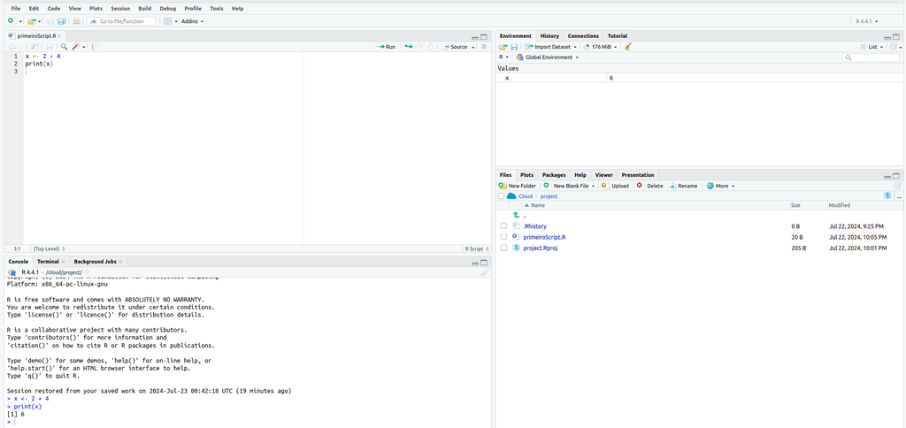

No editor de scripts escrevermos os códigos (scripts) que serão responsáveis por realizar os cálculos e outras funções que programamos.

No console executamos os códigos e recebemos as saídas.

As outras janelas servem a nos auxiliar. Mostram saídas de gráficos, quais variáveis estão no ambiente, dados carregados, pacotes instalados, etc.

Acima das quatro janelas descritas estão as opções do RStudio.

Como falamos acima, aos poucos vamos entendendo como tudo funciona. Nas próximas seções faremos alguns exercícios que ajudam a explorar e entender melhor as funcionalidades do RStudio.

### 7.1.1 Algumas configurações importantes

**.RData e .Rhistory**

O RStudio possui duas funcionalidades que são muito boas para usuários mais experientes, mas que podem atrapalhar o aprendizado do R. Por isso é recomendado que sejam desativadas, por enquanto.

Para isso vá na opção ferramentas (tools) no menu superior e depois em opções gerais (general options). Desmarque a opção *Restore .RData* e *Always save history*.

Suas opções devem ficar como na image abaixo:

[figure not shown]

**Gerenciando projetos**

Tá, mas por que isso é importante?

Lembra quando falei de sabermos quando e como as alterações foram realizadas? Ao guardarmos os metadados, podemos manter as versões de nosso trabalho de forma mais segura e garantir que os arquivos criados para uma determinada finalidade estejam sempre na mesma pasta. Nada de perder arquivos depois de horas, porque eles ficaram em alguma pasta temporária do sistema.

Para fazer isso, primeiro vamos alterar as opções no RStudio para que ele sempre guarde os arquivos em uma pasta que sabemos onde está. Para isso siga o seguinte passo-a-passo:

1. Vá em tools (ferramentas) -> general options -> RSessions -> Browser
2. Uma nova janela vai se abrir
3. Clique em New Folder
4. Da mesma forma que você cria novas pastas no sistema operacional, crie uma pasta exclusiva para seus projetos do RStudio. Eu costumo chamar essa pasta de projetosR.
5. Clique em choose (escolher)
6. Cliqeu em applay e depois OK

Agora o RStudio sempre salvará seus arquivos dentro desta pasta.

[figure not shown]

Uma vez que sua pasta de trabalho padrão está criada. Cada vez que criar um projeto, ele será uma subpasta do diretório principal.

**Para criar um projeto** vá até o menu superior e clique em *file* -> *new project*. O programa dará as opções de criar uma nova pasta no computador, de usar um pasta já existente ou de conectar-se a um repositório GIT (incluindo repositórios no GitHub).

Lembra que um dos pilares desse curso é despertar a autonomia no uso do R e suas ferramentas? Agora é sua vez de explorar a interface do RStudio.

*Exercício:* criar três projetos diferentes, um para cada opção disponível no RStudio.

[figure not shown]

Agora que nosso ambiente de trabalho está configurado e testado. Vamos começar a usar o R dentro do RStudio.